# Assignment 4: Advanced Visualization

Pierre Wensel

23 November, 2023

# 1 ASSIGNMENT4

Exercises: Create new plots for genetic data visualization using the SNPdataset.txt dataset. Create a report in .html format and briefly describe each one of the plots. This assignment includes the following:

_1. Problem 1a and b

_2. Problem 2a, b, and c

_3. Problem 3

_4. Problem 4

#1a:Analyze the distribution of the variable GENE_EXPRESSION.Create a histogram and a boxplot to analyze the distribution of the variable GENE_EXPRESSION. Display them together (hint: use ggarrange).

```r
#Reading data set file and creating data frame

snpdata <- read.table("SNPdataset.txt", header=T, sep="")
head(snpdata)
```

```
##   CASECONTROL SNP1 SNP2 SNP3 SNP4 SNP5 GENE_EXPRESSION AGE GENDER
## 1           1   TT   GG   AA   AA   CC        75640.52  43 Female
## 2           1   TT   CG   AA   AC   AC        28688.22  45 Female
## 3           1   TT   GG   AA   CC   CC        17279.59  47 Female
## 4           1   CT   GG   AA   AC   CC        27253.99  35   Male
## 5           1   TT   GG   AA   AC   AC        38066.57  38 Female
## 6           1   TT   GG   AA   AA   CC         9872.46  32 Female
```

```r
#Indicates rows with missing data
complete.cases(snpdata)
```

```
##   [1]  TRUE  TRUE  TRUE  TRUE  TRUE  TRUE  TRUE  TRUE  TRUE  TRUE  TRUE  TRUE
##  [13]  TRUE  TRUE  TRUE  TRUE  TRUE  TRUE  TRUE FALSE  TRUE  TRUE FALSE  TRUE
##  [25]  TRUE  TRUE  TRUE  TRUE  TRUE FALSE  TRUE  TRUE FALSE  TRUE  TRUE  TRUE
##  [37]  TRUE  TRUE  TRUE  TRUE  TRUE  TRUE  TRUE  TRUE  TRUE  TRUE  TRUE  TRUE
##  [49]  TRUE  TRUE  TRUE  TRUE FALSE  TRUE  TRUE  TRUE  TRUE  TRUE  TRUE  TRUE
##  [61]  TRUE  TRUE  TRUE  TRUE  TRUE  TRUE  TRUE  TRUE  TRUE  TRUE  TRUE  TRUE
##  [73]  TRUE FALSE FALSE  TRUE  TRUE FALSE  TRUE  TRUE  TRUE  TRUE FALSE  TRUE
##  [85]  TRUE  TRUE  TRUE  TRUE  TRUE  TRUE  TRUE  TRUE  TRUE  TRUE  TRUE  TRUE
##  [97]  TRUE  TRUE FALSE  TRUE  TRUE  TRUE  TRUE  TRUE  TRUE  TRUE FALSE  TRUE
## [109]  TRUE  TRUE  TRUE  TRUE  TRUE  TRUE  TRUE  TRUE  TRUE  TRUE  TRUE  TRUE
## [121]  TRUE  TRUE  TRUE  TRUE  TRUE  TRUE  TRUE  TRUE  TRUE  TRUE  TRUE  TRUE
## [133]  TRUE  TRUE  TRUE FALSE FALSE  TRUE  TRUE  TRUE  TRUE FALSE  TRUE  TRUE
## [145]  TRUE  TRUE  TRUE  TRUE  TRUE FALSE  TRUE  TRUE  TRUE  TRUE  TRUE  TRUE
## [157]  TRUE
```

```r
#Removing rows with empty data and creating new data frame
csnpdata<-snpdata[complete.cases(snpdata),]

#Factoring categorical data before plotting
csnpdata$CASECONTROL <- factor(csnpdata$CASECONTROL, levels=c(0,1), labels = c("Control", "Case"))

csnpdata$GENDER <- factor(csnpdata$GENDER, levels=c("Female","Male"))

#Examining data of dataframe before plotting
head(csnpdata)
```

```
##   CASECONTROL SNP1 SNP2 SNP3 SNP4 SNP5 GENE_EXPRESSION AGE GENDER
## 1        Case   TT   GG   AA   AA   CC        75640.52  43 Female
## 2        Case   TT   CG   AA   AC   AC        28688.22  45 Female
## 3        Case   TT   GG   AA   CC   CC        17279.59  47 Female
## 4        Case   CT   GG   AA   AC   CC        27253.99  35   Male
## 5        Case   TT   GG   AA   AC   AC        38066.57  38 Female
## 6        Case   TT   GG   AA   AA   CC         9872.46  32 Female
```

```r
#Finding maximum gene expression to set scale of histogram
max(csnpdata$GENE_EXPRESSION)
```

```
## [1] 123334.1
```

```r
#Examining all data with complete rows before plotting
complete.cases(csnpdata)
```

```
##   [1] TRUE TRUE TRUE TRUE TRUE TRUE TRUE TRUE TRUE TRUE TRUE TRUE TRUE TRUE TRUE
##  [16] TRUE TRUE TRUE TRUE TRUE TRUE TRUE TRUE TRUE TRUE TRUE TRUE TRUE TRUE TRUE
##  [31] TRUE TRUE TRUE TRUE TRUE TRUE TRUE TRUE TRUE TRUE TRUE TRUE TRUE TRUE TRUE
##  [46] TRUE TRUE TRUE TRUE TRUE TRUE TRUE TRUE TRUE TRUE TRUE TRUE TRUE TRUE TRUE
##  [61] TRUE TRUE TRUE TRUE TRUE TRUE TRUE TRUE TRUE TRUE TRUE TRUE TRUE TRUE TRUE
##  [76] TRUE TRUE TRUE TRUE TRUE TRUE TRUE TRUE TRUE TRUE TRUE TRUE TRUE TRUE TRUE
##  [91] TRUE TRUE TRUE TRUE TRUE TRUE TRUE TRUE TRUE TRUE TRUE TRUE TRUE TRUE TRUE
## [106] TRUE TRUE TRUE TRUE TRUE TRUE TRUE TRUE TRUE TRUE TRUE TRUE TRUE TRUE TRUE
## [121] TRUE TRUE TRUE TRUE TRUE TRUE TRUE TRUE TRUE TRUE TRUE TRUE TRUE TRUE TRUE
## [136] TRUE TRUE TRUE TRUE TRUE TRUE TRUE
```

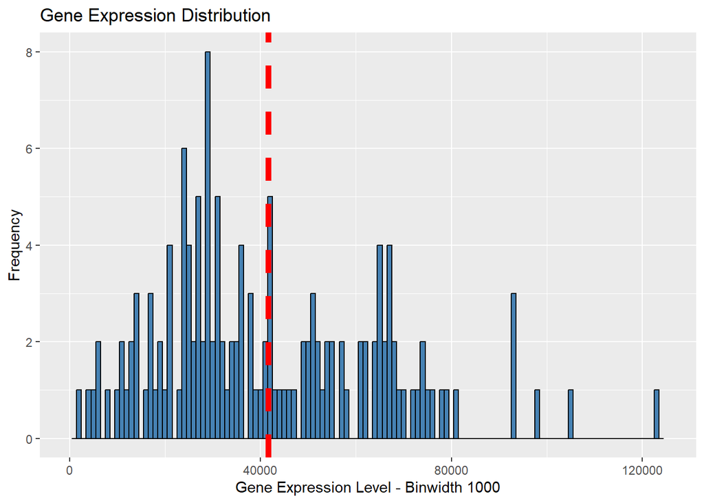

```r
#Creating Histogram
p1<-ggplot(data=csnpdata,aes(x=GENE_EXPRESSION)) +
  geom_histogram(binwidth=1000,color="black", fill="steelblue" ) +     ##### binwidth=change width histogram
  ggtitle("Gene Expression Distribution") +
  xlab("Gene Expression Level - Binwidth 1000") +
  ylab("Frequency") +
  xlim(0,125000) +
  geom_vline(aes(xintercept=mean(GENE_EXPRESSION)), color="red",linetype="dashed",lwd=2)

p1
```

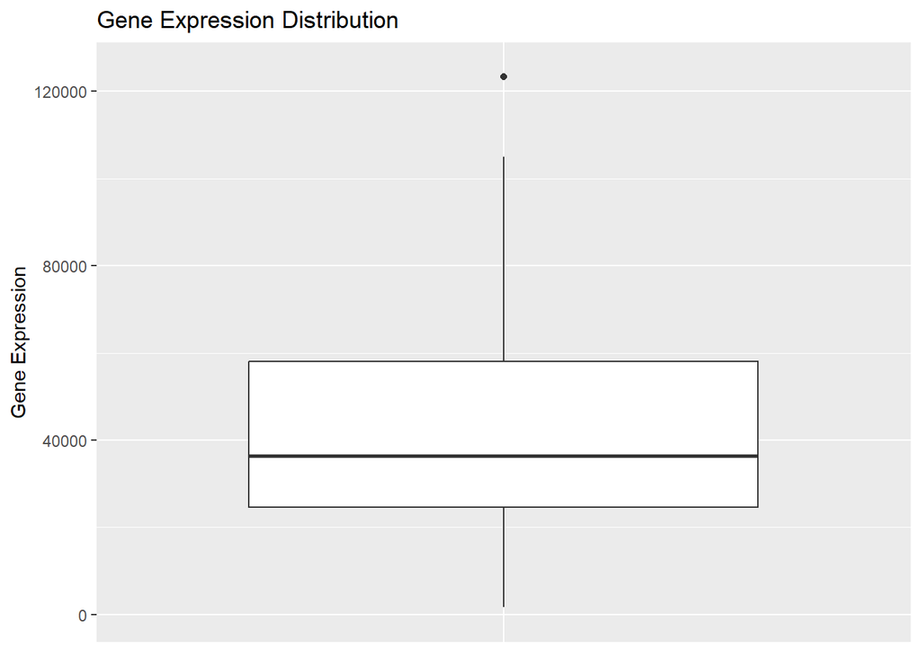

```r
#Creating Boxplot:
p2<-ggplot(csnpdata, aes(x=factor(0),y=GENE_EXPRESSION)) +
  geom_boxplot() + ggtitle("Gene Expression Distribution") +
  ylab("Gene Expression") +
  coord_cartesian(ylim=c(0,125000)) +
  theme(axis.title.x=element_blank(),## removes title in the x-axis
        axis.text.x=element_blank(), ###removes text ===> 0 in the x-axis
        axis.ticks.x=element_blank()) ## removes the tick (line)

p2
```

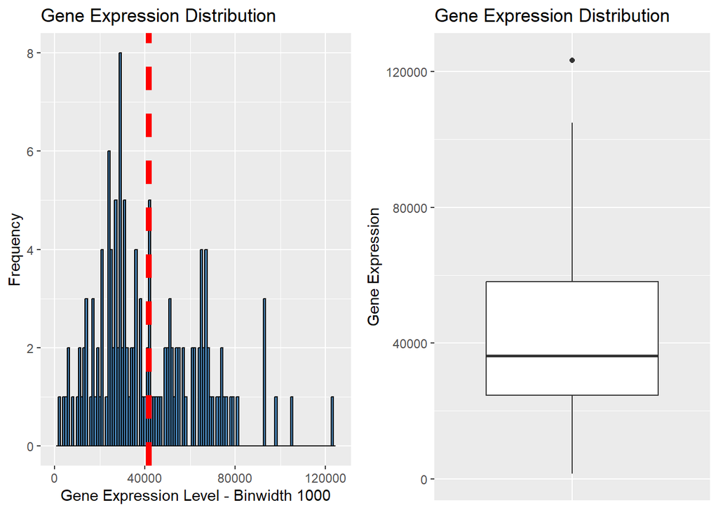

```r
#Arranging both histogram and boxplot on same line:
ggarrange(ncol=2, nrow=1, p1,p2) ## ggarrange allows us to plot together different plots: we can define number of columns (ncol) and number of rows(nrow) to divide the area where we want to add the plots
```

#1B:Create a histogram and a boxplot to analyze the distribution of the variable GENE_EXPRESSION both in women and in men. Show a single histogram to compare the distribution of the variable between sexes. (hint: overlap both histograms and color the distribution for women in green and for men in blue). For the boxplot, also fill the figure in green for women and in blue for men (hint: take a look to the argument scale_fill_manual).

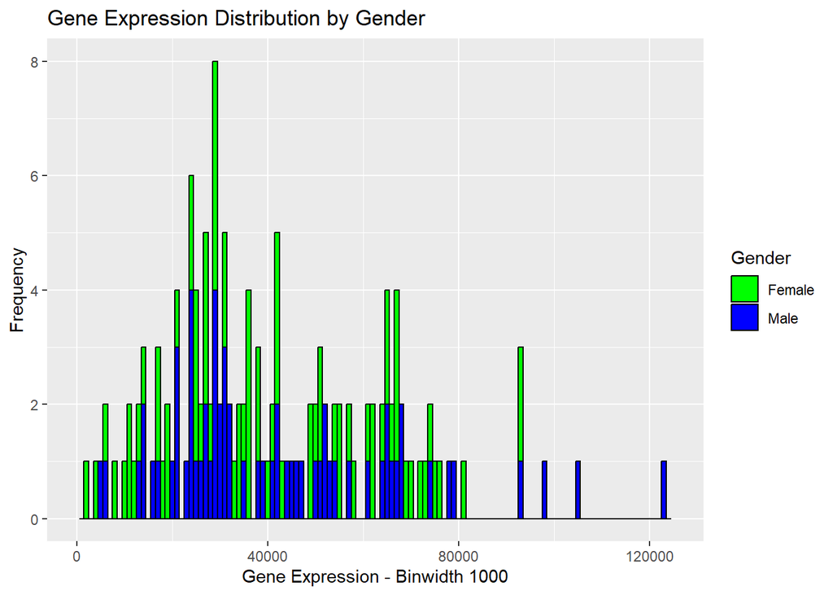

```r
#Creating histogram
p4<-ggplot(csnpdata, aes(x=GENE_EXPRESSION)) +
  geom_histogram(binwidth=1000, aes(fill=GENDER),color="black") +
  ggtitle("Gene Expression Distribution by Gender") +
  xlab("Gene Expression - Binwidth 1000") + ylab("Frequency") + xlim(0,125000) +
  theme(legend.position = "right") +
  scale_fill_manual(name = "Gender", labels = c("Female", "Male"),values = c("green", "blue"))
p4
```

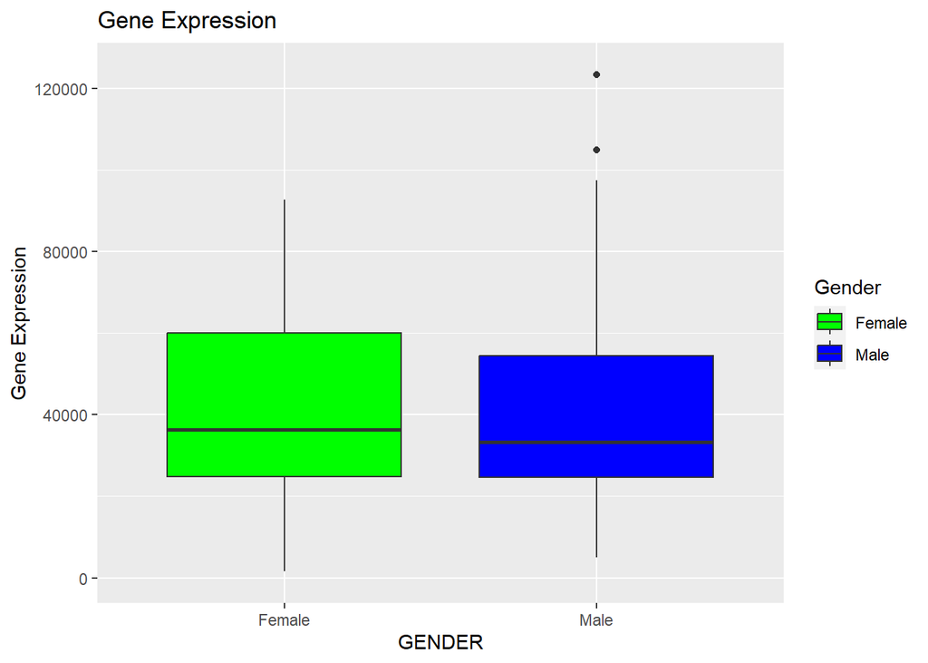

```r
#Creating boxplot
p5<-ggplot(csnpdata, aes(x=GENDER,y=GENE_EXPRESSION, fill=GENDER)) +
  geom_boxplot() + ggtitle("Gene Expression") +
  ylab("Gene Expression") +
  coord_cartesian(ylim=c(0,125000)) +
  theme(legend.position = "right") +
  scale_fill_manual(name = "Gender", labels = c("Female", "Male"),values = c("green", "blue"))
p5
```

#2A Analyze the proportion of Women and men displaying each one of the SNP1-related genotypes. Define the scale as percent (100%).

```r
#Creating BarpLot
#p6<-ggplot(csnpdata, aes(x=SNP1, fill=GENDER)) +
#  geom_bar(position = "fill") +
#  theme(legend.position = "right") +
#  scale_fill_manual(name = "Gender", labels = c("Female", "Male"),values = c("green", "blue"))
#p6

#Problem 2a Working without pipes:
#(No Pipes)
csnpdata_perc<- data.frame(round(prop.table(table(csnpdata$SNP1, csnpdata$GENDER),1)*100,2))
head(csnpdata_perc)
```

```
##   Var1   Var2  Freq
## 1   CC Female 36.36
## 2   CT Female 55.56
## 3   TT Female 56.98
## 4   CC   Male 63.64
## 5   CT   Male 44.44
## 6   TT   Male 43.02
```

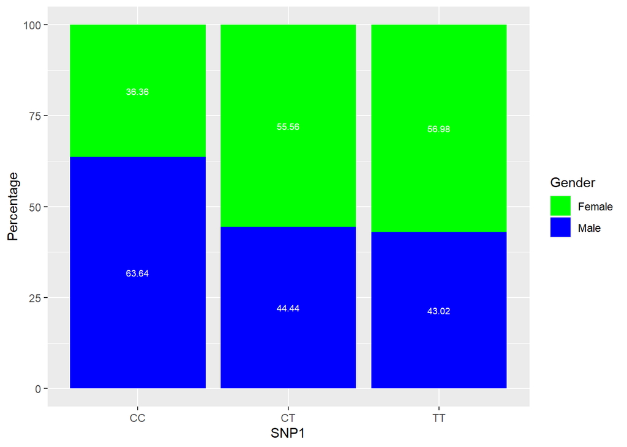

```r
colnames(csnpdata_perc)<-c("SNP1","GENDER","Percentage")

p7<-ggplot(csnpdata_perc, aes(x=SNP1, y=Percentage, fill=GENDER))+
  geom_bar(position="stack",stat="identity")+
  geom_text(aes(x=SNP1, y=Percentage, label=Percentage), position = position_stack(vjust = 0.5), size=2.5, color="white")+
  theme(legend.position = "right") +
  scale_fill_manual(name = "Gender", labels = c("Female", "Male"),values = c("green", "blue"))

p7
```

```r
#Problem 2a
#(working with pipes)
csnpdata_perc2<- csnpdata %>%
  group_by(SNP1, GENDER) %>%
  summarise(
    n=n()) %>%
  mutate(Proportion=n/sum(n))
```

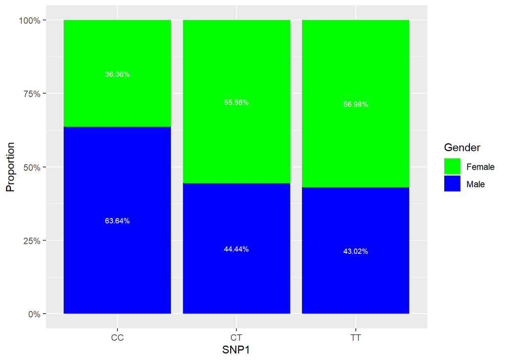

```r
csnpdata_perc2 %>%
  ggplot(aes(x=SNP1, y=Proportion, fill=GENDER)) +
  geom_bar(position="stack",stat="identity") +
  geom_text(aes(x=SNP1, y=Proportion, label=paste0(round(Proportion*100,2),"%")),
            position = position_stack(vjust = 0.5),
            size=2.5, color="white") +
  scale_y_continuous(labels = scales::percent_format())+
  theme(legend.position = "right") +
  scale_fill_manual(name = "Gender", labels = c("Female", "Male"),values = c("green", "blue"))
```

#2B Analyze the proportion of Individuals with different genotypes for SNP5 within cases and controls. Define the scale as unit (all the proportions should sum up to 1).

```r
#Problem 2b:
csnpdata_2B<- csnpdata %>%
  group_by(CASECONTROL, SNP5) %>%
  summarise(
    n=n()) %>%
  mutate(Proportion=n/sum(n))
```

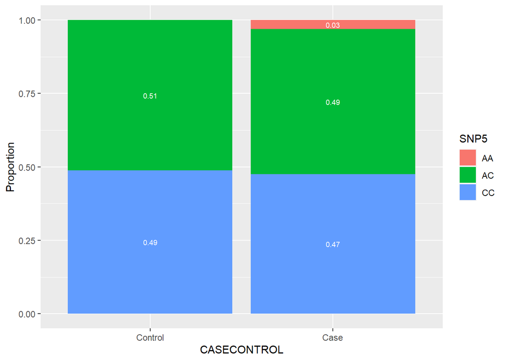

```r
csnpdata_2B %>%
  ggplot(aes(x=CASECONTROL, y=Proportion, fill=SNP5)) +
  geom_bar(position="stack",stat="identity") +
  geom_text(aes(x=CASECONTROL, y=Proportion, label=round(Proportion,2)),
            position = position_stack(vjust = 0.5),
            size=2.5, color="white")
```

#2C Analyze the proportion ofWomen and men within controls and cases when filtering by individuals older than 35.

```r
csnpdata_2C<- csnpdata %>% filter(AGE > 35) %>%
  group_by(CASECONTROL, GENDER) %>%
  summarise(
    n=n()) %>%
  mutate(Proportion=n/sum(n))
```

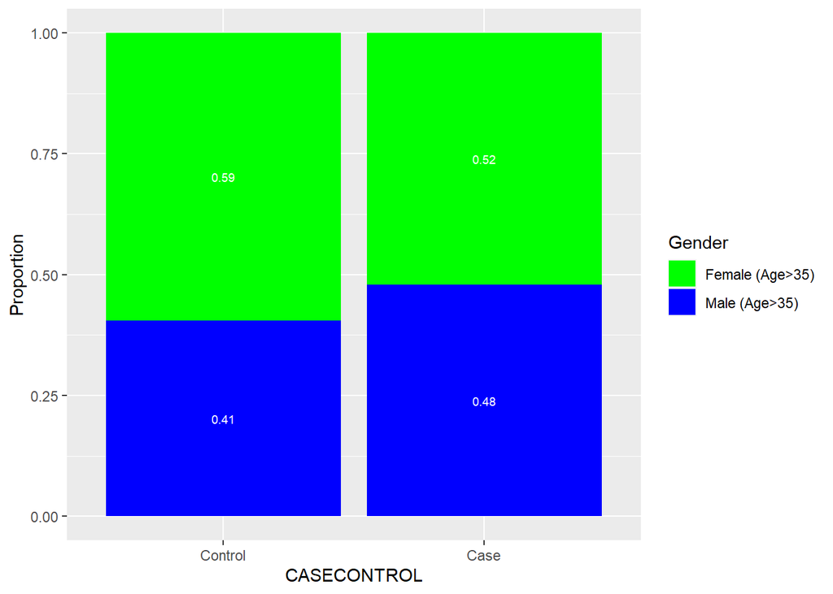

```r
csnpdata_2C %>%
  ggplot(aes(x=CASECONTROL, y=Proportion, fill=GENDER)) +
  geom_bar(position="stack",stat="identity") +
  geom_text(aes(x=CASECONTROL, y=Proportion, label=round(Proportion,2)),
            position = position_stack(vjust = 0.5),
            size=2.5, color="white")+theme(legend.position = "right") +
  scale_fill_manual(name = "Gender", labels = c("Female (Age>35)", "Male (Age>35)"),values = c("green", "blue"))
```

#3. Use facet wrap to show the frequency of each genotype of SNP1 for women and for men and color the bars according to the genotype (hint: you will work with geom_bar to display frequency).

```r
csnpdata_facetwrap<- data.frame(round(prop.table(table(csnpdata$GENDER, csnpdata$SNP1),1)*100,2))
head(csnpdata_facetwrap)
```

```
##     Var1 Var2  Freq
## 1 Female   CC  5.13
## 2   Male   CC 10.94
## 3 Female   CT 32.05
## 4   Male   CT 31.25
## 5 Female   TT 62.82
## 6   Male   TT 57.81
```

```r
colnames(csnpdata_facetwrap)<-c("GENDER","SNP1","Percentage")

p9<-ggplot(csnpdata_facetwrap, aes(x=GENDER, y=Percentage, fill=SNP1))+
  geom_bar(position="dodge",stat="identity")+ ggtitle("Genotype Proportions")+
  ylab("Proportions")+ theme(legend.position = "none")+
  coord_cartesian(ylim=c(0,100))+facet_wrap(GENDER~., scales="free") + geom_text(aes(x=GENDER, y=Percentage, label=Percentage), position = position_stack(vjust = 0.5), size=2.5, color="black")+
  theme_light() +
  theme(strip.text = element_text(face="bold", size=9, colour = "black")) +
  theme(strip.background = element_rect(fill="lightgray", colour="black",size=1))
  theme(legend.position = "right")
```

```
## List of 1
##  $ legend.position: chr "right"
##  - attr(*, "class")= chr [1:2] "theme" "gg"
##  - attr(*, "complete")= logi FALSE
##  - attr(*, "validate")= logi TRUE
```

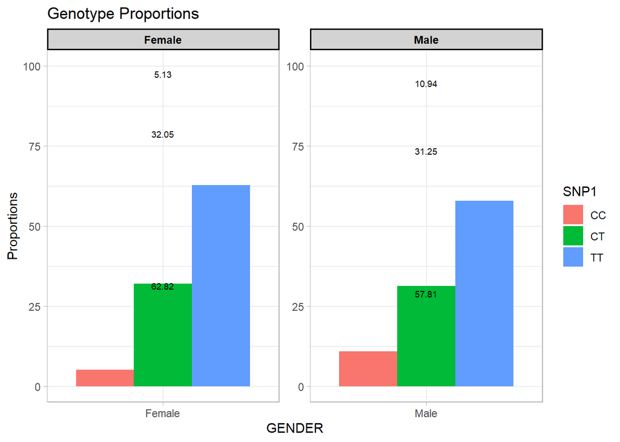

```r
p9
```

```r
#Performing Data Transformation
snps_long<- csnpdata %>% pivot_longer(
  cols=2:6,
  names_to="SNP",
  values_to="Genotype"
)

csnpdata_facetgrid<- data.frame(round(prop.table(table(snps_long$GENDER, snps_long$SNP),1)*100,2))
head(csnpdata_facetgrid)
```

```
##     Var1 Var2 Freq
## 1 Female SNP1   20
## 2   Male SNP1   20
## 3 Female SNP2   20
## 4   Male SNP2   20
## 5 Female SNP3   20
## 6   Male SNP3   20
```

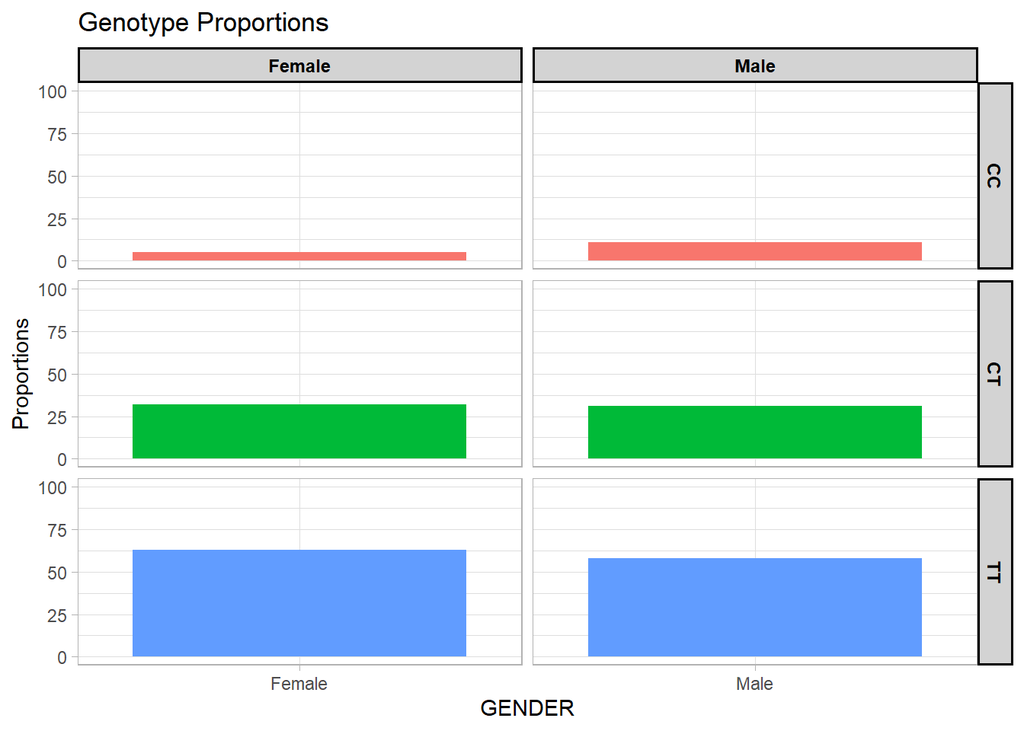

```r
colnames(csnpdata_facetwrap)<-c("GENDER","SNP","Percentage")

p10<-ggplot(csnpdata_facetwrap, aes(x=GENDER, y=Percentage, fill=SNP))+
  geom_bar(position="dodge",stat="identity")+ ggtitle("Genotype Proportions")+
  ylab("Proportions")+ coord_cartesian(ylim=c(0,100))+facet_grid(SNP~GENDER, scales="free") + theme_light() +
  theme(strip.text = element_text(face="bold", size=9, colour = "black")) +
  theme(strip.background = element_rect(fill="lightgray", colour="black",size=1))+theme(legend.position = "none")
p10
```